# GSE163668 Single-Cell RNA-seq Analysis

Author

Mohamed Ahmed Hamed

Published

October 21, 2026

# GSE163668 Single-Cell RNA-seq Analysis

This report runs the whole analysis from scratch on any machine: it downloads the raw data from GEO, performs QC, doublet removal, Harmony integration, clustering, annotation, pseudobulk differential expression (edgeR) and GSEA (GO Biological Process). Heavy steps are saved as checkpoints, so re-rendering is fast. Set `force_rerun <- TRUE` in section 2 to recompute everything.

## 1. Load required packages

```r
needed <- c(
  "Seurat", "SeuratObject", "SingleCellExperiment", "scDblFinder", "harmony",
  "dplyr", "tidyr", "ggplot2", "patchwork", "edgeR", "clusterProfiler",
  "org.Hs.eg.db", "enrichplot", "GEOquery", "stringr", "Matrix"
)

missing_pkgs <- needed[!vapply(needed, requireNamespace, logical(1), quietly = TRUE)]

if (length(missing_pkgs) > 0) {
  stop(
    "Missing packages: ", paste(missing_pkgs, collapse = ", "),
    "\nInstall them first, e.g. BiocManager::install(c(",
    paste0("\"", missing_pkgs, "\"", collapse = ", "), "))"
  )
}

if (!requireNamespace("presto", quietly = TRUE)) {
  message("Optional: install 'presto' (remotes::install_github('immunogenomics/presto')) for a much faster FindAllMarkers.")
}

library(Seurat)
library(SeuratObject)
library(SingleCellExperiment)
library(scDblFinder)
library(harmony)

library(dplyr)
library(ggplot2)
library(patchwork)

library(edgeR)
library(clusterProfiler)
library(org.Hs.eg.db)
library(enrichplot)
library(GEOquery)
library(stringr)
```

## 2. Define directories, flags and helpers

```r
set.seed(42)
options(timeout = 7200)

# ---------------------------------------------------------------
# EDIT THIS LINE ONLY: any folder with enough free disk space
# (the raw GEO archive + extracted files take several GB).
# ---------------------------------------------------------------
base_dir <- "D:/SUBSPACE_data/GSE163668"

raw_dir           <- file.path(base_dir, "raw")
extracted_dir     <- file.path(base_dir, "extracted")
final_project_dir <- file.path(base_dir, "FINAL_PROJECT")
fig_dir           <- file.path(final_project_dir, "Final_Figures")
gsea_dir          <- file.path(final_project_dir, "GSEA_eps0")
de_dir            <- file.path(base_dir, "DE_all_celltypes")
ckpt_dir          <- file.path(final_project_dir, "checkpoints")

for (d in c(raw_dir, extracted_dir, fig_dir, gsea_dir, de_dir, ckpt_dir)) {
  dir.create(d, recursive = TRUE, showWarnings = FALSE)
}

# Set TRUE to ignore all checkpoints and recompute everything.
force_rerun <- FALSE

n_expected_samples <- 38

clustered_rds  <- file.path(ckpt_dir, "01_sepsis_full_clustered.rds")
qc_rds         <- file.path(ckpt_dir, "02_qc_objects.rds")
markers_rds    <- file.path(base_dir, "markers_all_clusters.rds")
de_file        <- file.path(de_dir, "all_celltypes_edgeR_results.rds")
gsea_file      <- file.path(gsea_dir, "combined_GSEA_eps0.csv")

# Optional: manual annotation exported from the other machine (see section 16).
annotation_csv <- file.path(base_dir, "cell_type_annotation.csv")

# TRUE  -> run sections 3-13 (heavy preprocessing)
# FALSE -> load the saved clustered object instead
run_pre   <- force_rerun || !file.exists(clustered_rds)
use_cache <- !run_pre

cached <- function(path, expr) {
  if (!force_rerun && file.exists(path)) {
    return(readRDS(path))
  }
  res <- expr
  saveRDS(res, path)
  res
}

if (run_pre) {
  message("Preprocessing will run from scratch (no clustered checkpoint found).")
} else {
  message("Clustered checkpoint found: sections 3-13 are skipped and the object is loaded.")
}
```

# 3. Download and extract the raw data

The archive is downloaded from GEO only if the 38 matrix files are not already in `extracted_dir`.

```r
find_mtx <- function() {
  list.files(
    extracted_dir,
    pattern = "matrix\\.mtx\\.gz$",
    recursive = TRUE,
    full.names = TRUE
  )
}

if (length(find_mtx()) != n_expected_samples) {

  find_tar <- function() {
    list.files(raw_dir, pattern = "RAW\\.tar$", full.names = TRUE)
  }

  tar_dest <- file.path(raw_dir, "GSE163668_RAW.tar")

  urls <- c(
    "https://ftp.ncbi.nlm.nih.gov/geo/series/GSE163nnn/GSE163668/suppl/GSE163668_RAW.tar",
    "https://www.ncbi.nlm.nih.gov/geo/download/?acc=GSE163668&format=file",
    "ftp://ftp.ncbi.nlm.nih.gov/geo/series/GSE163nnn/GSE163668/suppl/GSE163668_RAW.tar"
  )

  for (u in urls) {
    if (length(find_tar()) > 0) break
    message("Trying: ", u)

    for (meth in c("libcurl", "wininet")) {
      if (meth == "wininet" && .Platform$OS.type != "windows") next
      if (length(find_tar()) > 0) break

      ok <- tryCatch(
        {
          download.file(u, destfile = tar_dest, mode = "wb", method = meth)
          TRUE
        },
        error = function(e) {
          message("  failed (", meth, "): ", conditionMessage(e))
          FALSE
        },
        warning = function(w) {
          message("  warning (", meth, "): ", conditionMessage(w))
          FALSE
        }
      )

      # Remove partial / failed downloads
      if (!ok && file.exists(tar_dest) && file.size(tar_dest) < 1e6) file.remove(tar_dest)
    }
  }

  if (length(find_tar()) == 0) {
    stop(
      "Could not download the GEO archive from this machine (network/firewall issue).\n",
      "Download 'GSE163668_RAW.tar' manually from\n",
      "https://www.ncbi.nlm.nih.gov/geo/query/acc.cgi?acc=GSE163668 (Supplementary file, 'http' link)\n",
      "or from a phone hotspot / another network, and put it in:\n  ", raw_dir,
      "\nThen render again; extraction is automatic."
    )
  }

  tar_path <- find_tar()[1]
  message("Extracting ", tar_path)
  untar(tar_path, exdir = extracted_dir)
}

length(find_mtx())
head(basename(find_mtx()), 5)
```

# 4. Read the 38 samples

```r
matrix_files <- sort(find_mtx())

if (length(matrix_files) != n_expected_samples) {
  stop(
    "Expected ", n_expected_samples, " matrix files in extracted_dir but found ",
    length(matrix_files), ". Check the folder and file names before rendering."
  )
}
```

```r
read_one_sample <- function(mtx_file) {

  prefix <- sub("matrix\\.mtx\\.gz$", "", mtx_file)
  sample_id <- sub("_matrix\\.mtx\\.gz$", "", basename(mtx_file))

  cells_file <- paste0(prefix, "barcodes.tsv.gz")

  features_file <- paste0(prefix, "features.tsv.gz")
  if (!file.exists(features_file)) {
    features_file <- paste0(prefix, "genes.tsv.gz")
  }

  stopifnot(file.exists(cells_file), file.exists(features_file))

  data <- ReadMtx(
    mtx = mtx_file,
    cells = cells_file,
    features = features_file,
    feature.column = 2
  )

  obj_sample <- CreateSeuratObject(
    counts = data,
    project = "GSE163668",
    min.cells = 3,
    min.features = 200
  )

  obj_sample$sample_id <- sample_id

  obj_sample
}

GSE163668_list <- lapply(matrix_files, read_one_sample)

names(GSE163668_list) <- vapply(
  GSE163668_list,
  function(x) x$sample_id[1],
  character(1)
)

length(GSE163668_list)
```

# 5. Quality control

## 5.1. Calculate mitochondrial percentage

```r
GSE163668_list <- lapply(
  GSE163668_list,
  function(x) {
    x[["percent.mt"]] <- PercentageFeatureSet(x, pattern = "^MT-")
    x
  }
)
```

## 5.2. QC before filtering

```r
qc_summary <- do.call(
  rbind,
  lapply(
    GSE163668_list,
    function(x) {
      data.frame(
        sample_id = x$sample_id[1],
        cells = ncol(x),
        median_features = median(x$nFeature_RNA),
        median_counts = median(x$nCount_RNA),
        median_mt = median(x$percent.mt),
        mean_mt = mean(x$percent.mt)
      )
    }
  )
)
rownames(qc_summary) <- NULL

qc_summary
```

```r
VlnPlot(
  GSE163668_list[[1]],
  features = c("nFeature_RNA", "nCount_RNA", "percent.mt"),
  ncol = 3,
  pt.size = 0
)
```

## 5.3. Cell filtering

```r
GSE163668_list <- lapply(
  GSE163668_list,
  function(x) {
    subset(
      x,
      subset =
        nFeature_RNA > 200 &
        nFeature_RNA < 6000 &
        percent.mt < 10
    )
  }
)
```

## 5.4. QC after filtering

```r
qc_after <- do.call(
  rbind,
  lapply(
    GSE163668_list,
    function(x) {
      data.frame(
        sample_id = x$sample_id[1],
        cells_after = ncol(x)
      )
    }
  )
)
rownames(qc_after) <- NULL

qc_after
```

# 6. Doublet detection

scDblFinder is run on raw counts of each library separately. The seed is fixed for reproducibility; if scDblFinder fails on a very small library, the sample is kept and flagged in the summary table.

```r
sample_names <- names(GSE163668_list)

GSE163668_list <- lapply(
  sample_names,
  function(nm) {

    x <- GSE163668_list[[nm]]

    counts <- LayerData(x, assay = "RNA", layer = "counts")
    sce <- SingleCellExperiment(assays = list(counts = counts))

    res <- tryCatch(
      {
        set.seed(42)
        scDblFinder(sce, verbose = FALSE)
      },
      error = function(e) {
        warning("scDblFinder failed for ", nm, ": ", conditionMessage(e))
        NULL
      }
    )

    if (is.null(res)) {
      x$doublet_class <- "singlet"
      x$doublet_score <- NA_real_
      x$doublet_failed <- TRUE
    } else {
      idx <- match(colnames(x), colnames(res))
      x$doublet_class <- as.character(res$scDblFinder.class[idx])
      x$doublet_score <- res$scDblFinder.score[idx]
      x$doublet_failed <- FALSE
    }

    x
  }
)

names(GSE163668_list) <- sample_names
```

## 6.1. Doublet summary

```r
doublet_table <- do.call(
  rbind,
  lapply(
    GSE163668_list,
    function(x) {
      data.frame(
        sample_id = x$sample_id[1],
        cells = ncol(x),
        doublets = sum(x$doublet_class == "doublet"),
        doublet_pct = round(100 * mean(x$doublet_class == "doublet"), 1),
        scdblfinder_failed = isTRUE(x$doublet_failed[1])
      )
    }
  )
)
rownames(doublet_table) <- NULL

doublet_table

table(unlist(lapply(GSE163668_list, function(x) x$doublet_class)))
```

## 6.2. Keep singlets

```r
GSE163668_list <- lapply(
  GSE163668_list,
  function(x) {
    subset(x, subset = doublet_class == "singlet")
  }
)
```

## 6.3. Final cell numbers after QC

```r
cell_counts_final <- vapply(GSE163668_list, ncol, numeric(1))

cell_counts_final
sum(cell_counts_final)
```

# 7. Normalize each sample

```r
GSE163668_list <- lapply(
  GSE163668_list,
  function(x) {

    x <- NormalizeData(
      x,
      normalization.method = "LogNormalize",
      scale.factor = 10000,
      verbose = FALSE
    )

    x <- FindVariableFeatures(
      x,
      selection.method = "vst",
      nfeatures = 2000,
      verbose = FALSE
    )

    x
  }
)
```

## 7.1. Check variable features

```r
all(
  vapply(
    GSE163668_list,
    function(x) length(VariableFeatures(x)) == 2000,
    logical(1)
  )
)

# Save the QC tables so the report can still show them when later
# renders reuse the clustered checkpoint.
saveRDS(
  list(
    qc_summary = qc_summary,
    qc_after = qc_after,
    doublet_table = doublet_table,
    cell_counts_final = cell_counts_final
  ),
  qc_rds
)
```

# 8. Merge all 38 samples and select integration features

```r
sepsis_full <- merge(
  x = GSE163668_list[[1]],
  y = GSE163668_list[-1],
  add.cell.ids = names(GSE163668_list),
  project = "GSE163668"
)

dim(sepsis_full)
length(Cells(sepsis_full))
```

```r
VariableFeatures(sepsis_full) <-
  SelectIntegrationFeatures(
    object.list = GSE163668_list,
    nfeatures = 2000
  )

length(VariableFeatures(sepsis_full))

# The per-sample list is no longer needed; free memory.
rm(GSE163668_list)
invisible(gc())
```

# 9. Scaling and PCA

```r
sepsis_full <- ScaleData(
  sepsis_full,
  features = VariableFeatures(sepsis_full),
  verbose = FALSE
)

sepsis_full <- RunPCA(
  sepsis_full,
  features = VariableFeatures(sepsis_full),
  npcs = 30,
  verbose = FALSE
)
```

# 10. Harmony batch correction

```r
# Harmony compatibility workaround:
# RunHarmony.Seurat in some installed package combinations passes the
# legacy argument assay.use to RunHarmony.default, which newer Harmony
# versions reject. Run Harmony directly on the PCA embeddings instead.
# The first two arguments are passed by position so the call works
# whatever the first argument is called in the installed Harmony version.

pca_embeddings <- Seurat::Embeddings(
  sepsis_full,
  reduction = "pca"
)[, 1:20, drop = FALSE]

harmony_metadata <- sepsis_full@meta.data[
  rownames(pca_embeddings),
  "sample_id",
  drop = FALSE
]

stopifnot(
  nrow(pca_embeddings) == nrow(harmony_metadata),
  !anyNA(harmony_metadata$sample_id)
)

harmony_embeddings <- harmony::RunHarmony(
  pca_embeddings,
  harmony_metadata,
  vars_use = "sample_id",
  verbose = FALSE
)

# Add corrected embeddings back to the Seurat object.
rownames(harmony_embeddings) <- rownames(pca_embeddings)
colnames(harmony_embeddings) <- paste0(
  "harmony_",
  seq_len(ncol(harmony_embeddings))
)

sepsis_full[["harmony"]] <- Seurat::CreateDimReducObject(
  embeddings = harmony_embeddings,
  key = "harmony_",
  assay = Seurat::DefaultAssay(sepsis_full)
)
```

# 11. Neighbors and clustering

```r
sepsis_full <- FindNeighbors(
  sepsis_full,
  reduction = "harmony",
  dims = 1:20,
  verbose = FALSE
)

sepsis_full <- FindClusters(
  sepsis_full,
  resolution = 0.5,
  random.seed = 42,
  verbose = FALSE
)
```

# 12. UMAP

```r
sepsis_full <- RunUMAP(
  sepsis_full,
  reduction = "harmony",
  dims = 1:20,
  seed.use = 42,
  verbose = FALSE
)
```

# 13. Prepare the object for downstream analysis and save the checkpoint

`scale.data` layers are not needed for the Wilcoxon markers or for pseudobulk DE and are very large, so they are dropped. The per-sample `counts` and `data` layers are then joined (required by `FindAllMarkers`).

```r
DefaultAssay(sepsis_full) <- "RNA"

rna_assay <- sepsis_full[["RNA"]]
scale_layers <- grep("^scale\\.data", Layers(rna_assay), value = TRUE)

for (l in scale_layers) {
  tryCatch(
    LayerData(rna_assay, layer = l) <- NULL,
    error = function(e) message("Could not drop layer ", l, ": ", conditionMessage(e))
  )
}

sepsis_full[["RNA"]] <- rna_assay
rm(rna_assay)
invisible(gc())

sepsis_full[["RNA"]] <- JoinLayers(sepsis_full[["RNA"]])

Layers(sepsis_full[["RNA"]])

saveRDS(sepsis_full, clustered_rds)
```

```r
sepsis_full <- readRDS(clustered_rds)
message("Loaded clustered checkpoint: ", ncol(sepsis_full), " cells.")
```

## 13.1. QC tables

```r
if (file.exists(qc_rds)) {
  qc_objects <- readRDS(qc_rds)

  print(qc_objects$qc_summary)
  print(qc_objects$qc_after)
  print(qc_objects$doublet_table)
  cat("Cells after QC and doublet removal:", sum(qc_objects$cell_counts_final), "\n")
} else {
  message("QC tables are not available (no QC checkpoint); run with force_rerun <- TRUE to regenerate them.")
}
```

```
                           sample_id cells median_features median_counts
1         GSM4995425_MVIR1-POOL-SCG1 10698           339.5         912.0
2         GSM4995426_MVIR1-POOL-SCG2  4652          1478.5        4024.5
3         GSM4995427_MVIR1-POOL-SCG3 12221           381.0         837.0
4         GSM4995428_MVIR1-POOL-SCG4  1335           297.0         491.0
5         GSM4995429_MVIR1-POOL-SCG8  4828           352.0         721.5
6         GSM4995430_MVIR1-POOL-SCG9  6520           309.0         652.0
7  GSM4995431_MVIR1-HS12-D0BLD1-SCG1  3448          1013.0        2105.0
8  GSM4995432_MVIR1-HS14-D0BLD1-SCG1  3241           434.0         836.0
9  GSM4995433_MVIR1-HS16-D0BLD1-SCG1  1761           276.0         491.0
10 GSM4995434_MVIR1-HS25-D0BLD1-SCG1  2944          1780.0        4760.0
11 GSM4995435_MVIR1-HS26-D0BLD1-SCG1  5246          1502.0        3794.0
12 GSM4995436_MVIR1-HS29-D0BLD1-SCG1  3823           755.0        1680.0
13 GSM4995437_MVIR1-HS31-D0BLD1-SCG1   867           402.0         899.0
14 GSM4995438_MVIR1-HS38-D0BLD1-SCG1  4041           336.0         741.0
```

[output cut: 181 more lines]

## 13.2. Elbow plot

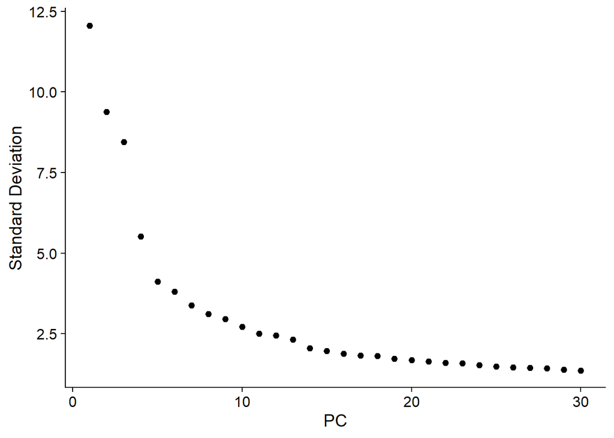

```r
ElbowPlot(sepsis_full, ndims = 30)
```

## 13.3. Basic object summary

```r
dim(sepsis_full)
```

```
[1] 24850 84947
```

```r
length(unique(sepsis_full$sample_id))
```

```
[1] 38
```

```r
table(sepsis_full$seurat_clusters)
```

```
    0     1     2     3     4     5     6     7     8     9    10    11    12
21531  8402  8311  6978  6037  5817  4820  4512  3605  3538  2705  2351  1545
   13    14    15    16    17    18    19    20    21
 1237  1074   878   748   344   223   164    67    60
```

## 13.4. UMAP by sample

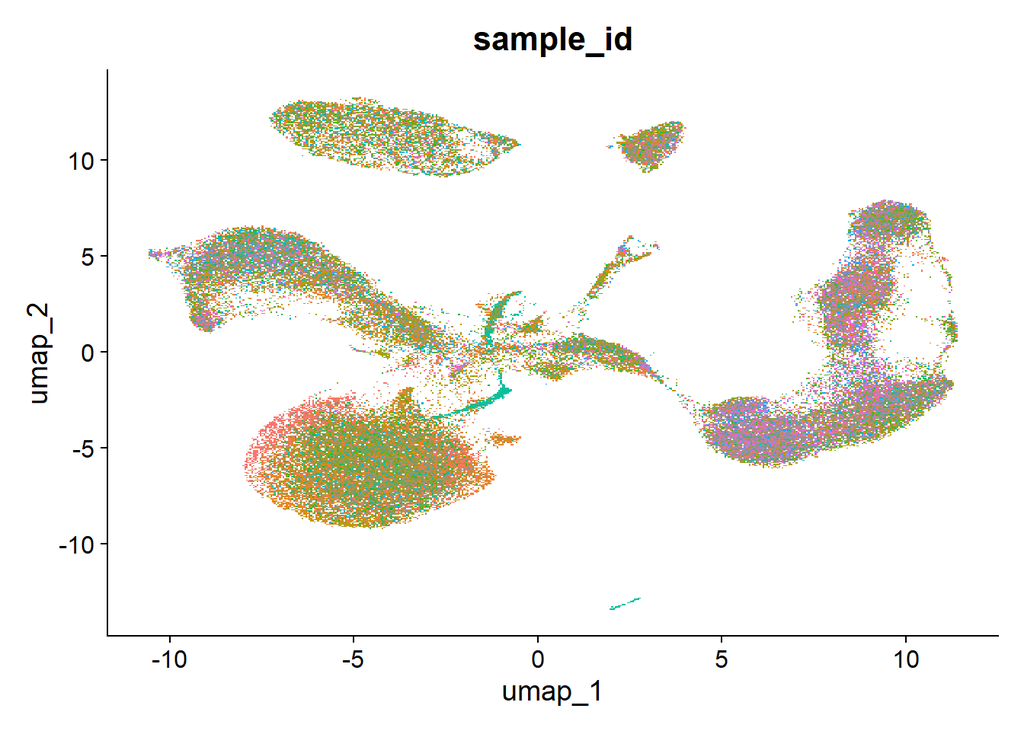

```r
DimPlot(
  sepsis_full,
  reduction = "umap",
  group.by = "sample_id",
  raster = TRUE
) + NoLegend()
```

## 13.5. UMAP by cluster

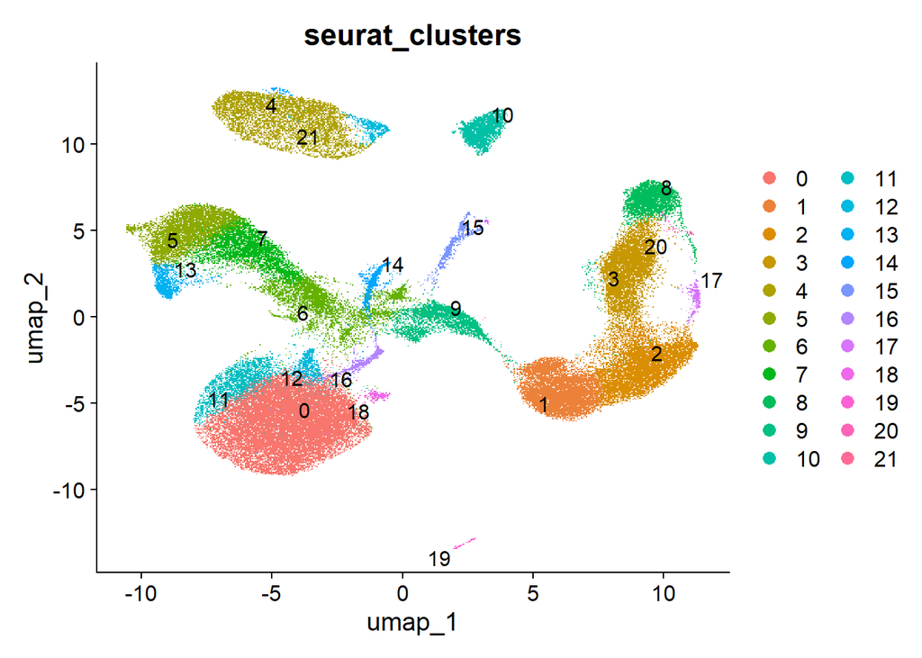

```r
DimPlot(
  sepsis_full,
  reduction = "umap",
  group.by = "seurat_clusters",
  label = TRUE,
  repel = TRUE,
  raster = TRUE
)
```

# 14. Cluster marker analysis

**Important:** This marker analysis uses all cells; no cell subsampling is performed.

```r
Idents(sepsis_full) <- "seurat_clusters"

markers <- cached(
  markers_rds,
  FindAllMarkers(
    sepsis_full,
    only.pos = TRUE,
    min.pct = 0.25,
    logfc.threshold = 0.25,
    test.use = "wilcox"
  )
)

markers %>%
  dplyr::group_by(cluster) %>%
  dplyr::slice_max(avg_log2FC, n = 5) %>%
  dplyr::ungroup() %>%
  as.data.frame()
```

```
            p_val avg_log2FC pct.1 pct.2     p_val_adj cluster          gene
1    0.000000e+00   4.520733 0.690 0.077  0.000000e+00       0        FCGR3B
2    0.000000e+00   4.421609 0.458 0.055  0.000000e+00       0         CXCR2
3    0.000000e+00   4.346798 0.317 0.032  0.000000e+00       0          G0S2
4    0.000000e+00   4.308942 0.444 0.039  0.000000e+00       0         CMTM2
5    0.000000e+00   3.933908 0.340 0.043  0.000000e+00       0     TNFRSF10C
6    0.000000e+00   4.023124 0.278 0.015  0.000000e+00       1         ADTRP
7    0.000000e+00   3.895432 0.747 0.062  0.000000e+00       1          CCR7
8    0.000000e+00   3.790277 0.282 0.019  0.000000e+00       1     CHRM3-AS2
9    0.000000e+00   3.539781 0.813 0.084  0.000000e+00       1          LEF1
10   0.000000e+00   3.513783 0.421 0.038  0.000000e+00       1       TRABD2A
11   0.000000e+00   4.070454 0.255 0.009  0.000000e+00       2       TNFRSF4
12   0.000000e+00   3.281311 0.634 0.066  0.000000e+00       2          AQP3
13   0.000000e+00   2.989383 0.373 0.035  0.000000e+00       2          CD28
14   0.000000e+00   2.982499 0.907 0.172  0.000000e+00       2          IL7R
```

[output cut: 96 more lines]

# 15. Cell-type annotation

Two modes are supported:

1. **Manual annotation (recommended for reproducing the original labels).** If `cell_type_annotation.csv` (columns `cell`, `cell_type`) exists in `base_dir`, labels are transferred by cell name. Cell names are `<sample_id>_<barcode>` and do not depend on cluster numbering. Create the file on the machine that has the annotated object with: `write.csv(data.frame(cell = colnames(sepsis_full), cell_type = sepsis_full$cell_type), "cell_type_annotation.csv", row.names = FALSE)`
2. **Automatic draft.** Otherwise each cluster is labelled by the canonical marker set with the highest z-scored module score. This is a draft: clusters flagged `needs_review` and the dot plot must be checked, and labels can be overridden with `manual_cluster_map`.

```r
marker_sets <- list(
  "Neutrophils"   = c("FCGR3B", "CSF3R", "CXCR2", "G0S2", "NAMPT", "S100A8", "S100A9", "IFITM2"),
  "Monocytes"     = c("CD14", "LYZ", "CST3", "FCN1", "VCAN", "LST1", "FCGR3A", "MS4A7"),
  "DC"            = c("FCER1A", "CD1C", "CLEC10A", "CLEC9A"),
  "pDC"           = c("LILRA4", "IRF7", "CLEC4C", "TCF4", "IL3RA", "PLD4"),
  "T cells"       = c("CD3D", "CD3E", "CD3G", "IL7R", "TRAC", "CD2", "LCK"),
  "NK cells"      = c("NKG7", "GNLY", "KLRD1", "KLRF1", "NCAM1", "PRF1", "GZMA"),
  "B cells"       = c("MS4A1", "CD79A", "CD79B", "BANK1", "CD19", "CD22"),
  "Plasmablasts"  = c("JCHAIN", "MZB1", "XBP1", "SDC1", "TNFRSF17", "PRDM1"),
  "Platelets"     = c("PPBP", "PF4", "GNG11", "TUBB1", "NRGN", "GP9", "CAVIN2"),
  "Erythroid"     = c("HBB", "HBA1", "HBA2", "ALAS2", "SLC4A1", "AHSP", "CA1", "GYPA"),
  "Cycling cells" = c("MKI67", "TOP2A", "STMN1", "TYMS", "PCLAF", "CENPF", "UBE2C")
)

marker_sets <- lapply(marker_sets, function(g) intersect(g, rownames(sepsis_full)))

# Optional manual override for the automatic mode, e.g. c("17" = "Cycling cells")
manual_cluster_map <- c()

cluster_ann <- NULL

if (file.exists(annotation_csv)) {

  ann <- read.csv(annotation_csv, stringsAsFactors = FALSE)
  stopifnot(all(c("cell", "cell_type") %in% colnames(ann)))

  ct <- ann$cell_type[match(colnames(sepsis_full), ann$cell)]
  matched_pct <- 100 * mean(!is.na(ct))

  message(sprintf("Manual annotation: %.1f%% of cells matched by name.", matched_pct))
  if (matched_pct < 95) {
    warning("Less than 95% of cells matched the annotation file. Check that sample names are identical.")
  }

  ct[is.na(ct)] <- "Unassigned"
  sepsis_full$cell_type <- ct
  annotation_source <- "manual annotation file"

} else {

  sepsis_full <- AddModuleScore(
    sepsis_full,
    features = marker_sets,
    name = "ms_",
    assay = "RNA",
    seed = 42
  )

  score_cols <- paste0("ms_", seq_along(marker_sets))
  ms <- sepsis_full@meta.data[, score_cols, drop = FALSE]
  colnames(ms) <- names(marker_sets)
  sepsis_full@meta.data[, score_cols] <- NULL

  cl_means <- aggregate(
    ms,
    by = list(cluster = as.character(sepsis_full$seurat_clusters)),
    FUN = mean
  )
  rownames(cl_means) <- cl_means$cluster

  z <- scale(as.matrix(cl_means[, names(marker_sets), drop = FALSE]))

  top_names <- t(apply(z, 1, function(r) names(sort(r, decreasing = TRUE))[1:2]))
  top_vals  <- t(apply(z, 1, function(r) sort(r, decreasing = TRUE)[1:2]))

  cluster_ann <- data.frame(
    cluster = rownames(z),
    auto_label = top_names[, 1],
    runner_up = top_names[, 2],
    z_top = round(top_vals[, 1], 2),
    z_margin = round(top_vals[, 1] - top_vals[, 2], 2),
    n_cells = as.vector(table(sepsis_full$seurat_clusters)[rownames(z)]),
    stringsAsFactors = FALSE
  )
  cluster_ann$needs_review <- cluster_ann$z_margin < 0.5
  cluster_ann <- cluster_ann[order(as.integer(cluster_ann$cluster)), ]
  rownames(cluster_ann) <- NULL

  cluster_ann$final_label <- cluster_ann$auto_label
  if (length(manual_cluster_map) > 0) {
    hit <- match(names(manual_cluster_map), cluster_ann$cluster)
    cluster_ann$final_label[hit] <- unname(manual_cluster_map)
  }

  sepsis_full$cell_type <- cluster_ann$final_label[
    match(as.character(sepsis_full$seurat_clusters), cluster_ann$cluster)
  ]

  annotation_source <- "automatic marker-based draft"
}

sepsis_full$cell_type <- as.character(sepsis_full$cell_type)
stopifnot(!anyNA(sepsis_full$cell_type))

cat("Annotation source:", annotation_source, "\n")
```

```
Annotation source: automatic marker-based draft
```

```r
if (!is.null(cluster_ann)) cluster_ann
```

```
   cluster    auto_label     runner_up z_top z_margin n_cells needs_review
1        0   Neutrophils           pDC  2.02     1.40   21531        FALSE
2        1       T cells Cycling cells  1.57     1.68    8402        FALSE
3        2       T cells  Plasmablasts  1.80     1.94    8311        FALSE
4        3      NK cells       T cells  1.83     0.18    6978         TRUE
5        4     Platelets     Monocytes  3.65     3.81    6037        FALSE
6        5            DC     Monocytes  2.03     0.07    5817         TRUE
7        6            DC     Monocytes  1.75     0.73    4820        FALSE
8        7     Monocytes   Neutrophils  1.96     1.54    4512        FALSE
9        8      NK cells  Plasmablasts  3.31     3.30    3605        FALSE
10       9       T cells      NK cells  0.81     0.64    3538        FALSE
11      10       B cells           pDC  4.42     3.06    2705        FALSE
12      11   Neutrophils     Monocytes  1.60     1.42    2351        FALSE
13      12     Platelets   Neutrophils  1.62     0.57    1545        FALSE
14      13     Monocytes           pDC  1.75     1.03    1237        FALSE
```

[output cut: 31 more lines]

```r
sort(table(sepsis_full$cell_type), decreasing = TRUE)
```

```
  Neutrophils       T cells            DC      NK cells     Platelets
        24269         20318         10697         10583          7582
    Monocytes       B cells     Erythroid  Plasmablasts Cycling cells
         5749          2705          1822           878           344
```

## 15.1. Marker check for the annotation

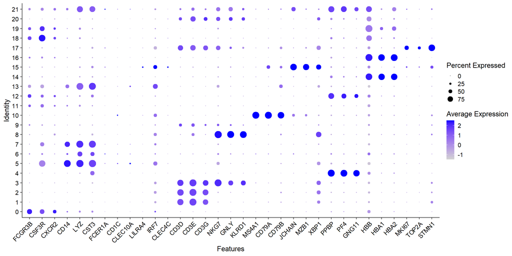

```r
dot_genes <- unique(unlist(lapply(marker_sets, head, 3)))

DotPlot(
  sepsis_full,
  features = dot_genes,
  group.by = "seurat_clusters"
) +
  RotatedAxis()
```

# 16. UMAP by annotated cell type

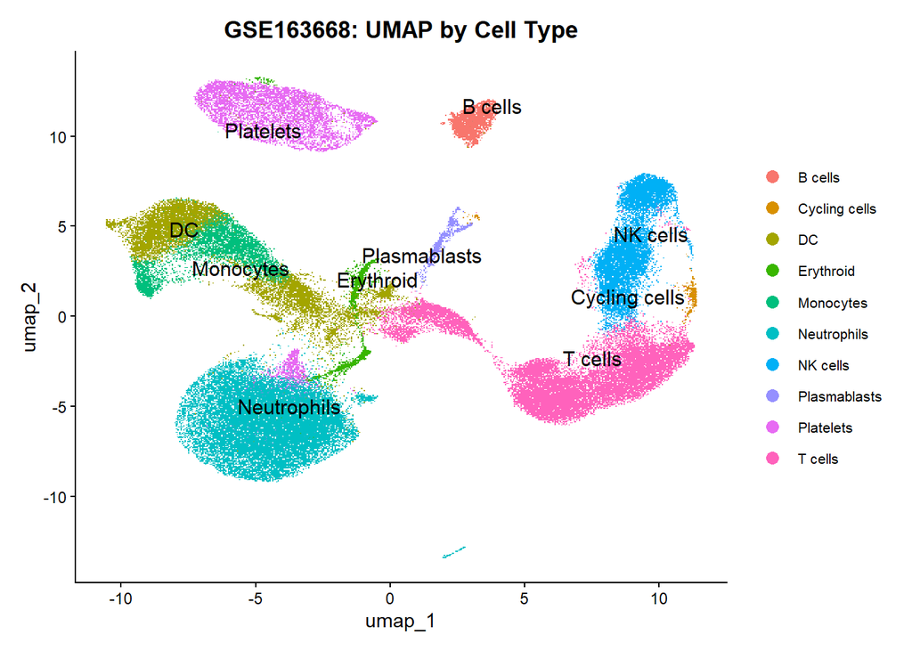

```r
Idents(sepsis_full) <- "cell_type"

p_umap_celltype <- DimPlot(
  sepsis_full,
  reduction = "umap",
  group.by = "cell_type",
  label = TRUE,
  repel = TRUE,
  raster = TRUE
) +
  ggtitle("GSE163668: UMAP by Cell Type") +
  theme_classic() +
  theme(
    plot.title = element_text(hjust = 0.5, face = "bold"),
    legend.text = element_text(size = 8)
  )

p_umap_celltype
```

# 17. Clinical group annotation

```r
pheno_csv <- file.path(ckpt_dir, "GSE163668_sample_metadata.csv")

if (file.exists(pheno_csv)) {

  pheno2 <- read.csv(pheno_csv, stringsAsFactors = FALSE)

} else {

  gse <- tryCatch(
    getGEO("GSE163668", GSEMatrix = FALSE, destdir = raw_dir),
    error = function(e) {
      stop(
        "Could not download the GEO sample metadata (no internet / cannot reach NCBI).\n",
        "Connect to the internet and render again. Everything before this step is saved,\n",
        "so the next render resumes quickly and only this step needs the connection.\n\n",
        "Original error: ", conditionMessage(e)
      )
    }
  )

  pheno2 <- do.call(
    rbind,
    lapply(
      GSMList(gse),
      function(g) {
        data.frame(
          gsm = Meta(g)$geo_accession,
          title = Meta(g)$title,
          characteristics = paste(Meta(g)$characteristics_ch1, collapse = " | "),
          stringsAsFactors = FALSE
        )
      }
    )
  )
  rownames(pheno2) <- NULL

  write.csv(pheno2, pheno_csv, row.names = FALSE)
}

nrow(pheno2)
```

```
[1] 38
```

```r
sample_meta <- pheno2 %>%
  dplyr::transmute(
    gsm = gsm,
    title = title,
    pooled = str_detect(characteristics, "pooled: TRUE"),
    covid_status = str_trim(
      str_match(characteristics, "covid_status: ([^|]+)")[, 2]
    ),
    phenotype = str_trim(
      str_match(characteristics, "phenotype: ([^|]+)")[, 2]
    )
  ) %>%
  dplyr::mutate(
    group = dplyr::case_when(
      pooled ~ "Pooled",
      phenotype == "CONTROL" ~ "Control",
      covid_status == "POSITIVE" & phenotype == "SEVERE" ~ "COVID_SEVERE",
      covid_status == "POSITIVE" & phenotype == "M/M" ~ "COVID_MM",
      covid_status == "NEGATIVE" ~ "COVID_NEG_patient",
      TRUE ~ NA_character_
    )
  )

table(sample_meta$group, useNA = "ifany")
```

```
          Control          COVID_MM COVID_NEG_patient      COVID_SEVERE
               14                 8                 5                 5
           Pooled
                6
```

```r
sepsis_full$gsm <- sub("_.*", "", sepsis_full$sample_id)

idx <- match(sepsis_full$gsm, sample_meta$gsm)

sepsis_full$group  <- sample_meta$group[idx]
sepsis_full$pooled <- sample_meta$pooled[idx]

if (anyNA(sepsis_full$group)) {
  bad_gsm <- unique(sepsis_full$gsm[is.na(sepsis_full$group)])
  stop(
    "Some cells could not be assigned to a clinical group. Problem GSM ids: ",
    paste(bad_gsm, collapse = ", ")
  )
}

group_levels <- c("Control", "COVID_NEG_patient", "COVID_MM", "COVID_SEVERE", "Pooled")

table(sepsis_full$group, useNA = "ifany")
```

```
          Control          COVID_MM COVID_NEG_patient      COVID_SEVERE
            19003             19674              6419              8489
           Pooled
            31362
```

# 18. UMAP by clinical group

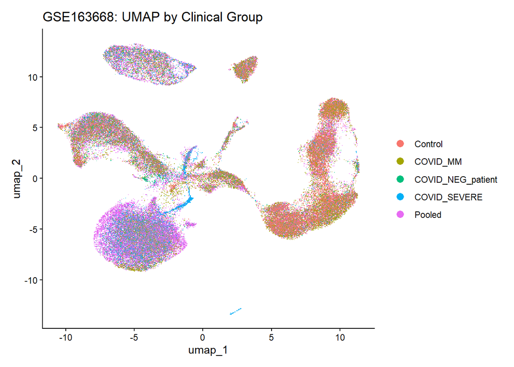

```r
p_umap_group <- DimPlot(
  sepsis_full,
  reduction = "umap",
  group.by = "group",
  raster = TRUE
) +
  ggtitle("GSE163668: UMAP by Clinical Group") +
  theme_classic()

p_umap_group
```

# 19. Cell counts by clinical group

```r
group_counts <- as.data.frame(table(sepsis_full$group))
colnames(group_counts) <- c("Group", "Number_of_Cells")

# Counts from the earlier analysis run, shown only as a sanity check.
previous_counts <- c(
  Control = 19029,
  COVID_MM = 19722,
  COVID_NEG_patient = 6412,
  COVID_SEVERE = 8503,
  Pooled = 31229
)

group_counts$Previous_run <- previous_counts[as.character(group_counts$Group)]

group_counts
```

```
              Group Number_of_Cells Previous_run
1           Control           19003        19029
2          COVID_MM           19674        19722
3 COVID_NEG_patient            6419         6412
4      COVID_SEVERE            8489         8503
5            Pooled           31362        31229
```

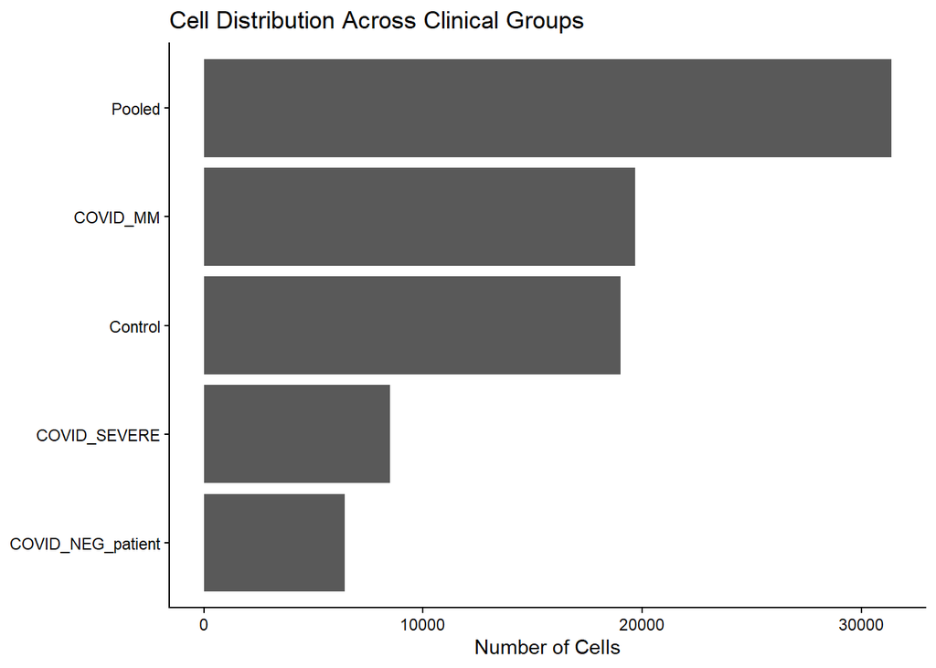

```r
p_group_counts <- ggplot(
  group_counts,
  aes(x = reorder(Group, Number_of_Cells), y = Number_of_Cells)
) +
  geom_col() +
  coord_flip() +
  labs(
    title = "Cell Distribution Across Clinical Groups",
    x = NULL,
    y = "Number of Cells"
  ) +
  theme_classic()

p_group_counts
```

# 20. Cell-type composition by clinical group

Composition is computed per biological sample (pooled multi-patient libraries are excluded because they cannot be assigned to one group).

```r
meta_np <- sepsis_full@meta.data %>%
  dplyr::filter(group != "Pooled", cell_type != "Unassigned")

comp_tab <- table(meta_np$sample_id, meta_np$cell_type)

comp_prop <- as.data.frame(prop.table(comp_tab, margin = 1), stringsAsFactors = FALSE)
colnames(comp_prop) <- c("sample_id", "cell_type", "proportion")
comp_prop$group <- meta_np$group[match(comp_prop$sample_id, meta_np$sample_id)]
comp_prop$group <- factor(
  comp_prop$group,
  levels = c("Control", "COVID_NEG_patient", "COVID_MM", "COVID_SEVERE")
)

write.csv(
  comp_prop,
  file.path(fig_dir, "Cell_type_proportions_per_sample.csv"),
  row.names = FALSE
)

comp_test <- do.call(
  rbind,
  lapply(
    unique(comp_prop$cell_type),
    function(ct) {
      d <- comp_prop[
        comp_prop$cell_type == ct &
          comp_prop$group %in% c("COVID_MM", "COVID_SEVERE"),
      ]
      d$group <- droplevels(d$group)
      if (nlevels(d$group) < 2) return(NULL)

      data.frame(
        cell_type = ct,
        median_prop_MM = median(d$proportion[d$group == "COVID_MM"]),
        median_prop_SEVERE = median(d$proportion[d$group == "COVID_SEVERE"]),
        p_value = tryCatch(
          wilcox.test(proportion ~ group, data = d, exact = FALSE)$p.value,
          error = function(e) NA_real_
        )
      )
    }
  )
)

if (!is.null(comp_test) && nrow(comp_test) > 0) {
  comp_test$p_adj <- p.adjust(comp_test$p_value, method = "BH")
  comp_test <- comp_test[order(comp_test$p_value), ]
  rownames(comp_test) <- NULL
}

comp_test
```

```
       cell_type median_prop_MM median_prop_SEVERE     p_value      p_adj
1        T cells    0.276378293        0.065793304 0.004310358 0.04310358
2      Platelets    0.053549046        0.163475700 0.023270292 0.11262946
3       NK cells    0.129415361        0.020618557 0.033788839 0.11262946
4    Neutrophils    0.159603672        0.254786451 0.272253581 0.42668664
5   Plasmablasts    0.013190201        0.007850242 0.272253581 0.42668664
6      Erythroid    0.004995329        0.017758370 0.341349314 0.42668664
7             DC    0.156566071        0.085702341 0.341349314 0.42668664
8      Monocytes    0.086272044        0.047658863 0.341349314 0.42668664
9        B cells    0.023712885        0.022091311 0.557643013 0.61960335
10 Cycling cells    0.004306213        0.006038647 0.941572761 0.94157276
```

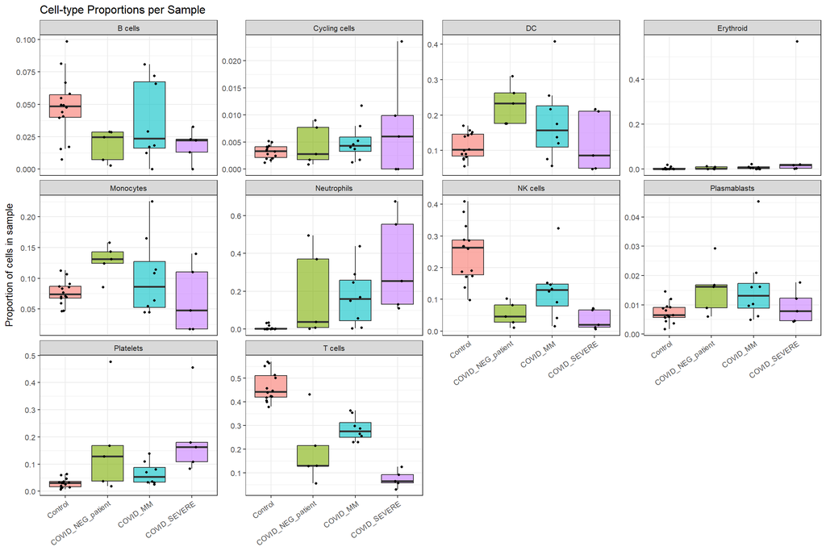

```r
p_composition <- ggplot(
  comp_prop,
  aes(x = group, y = proportion, fill = group)
) +
  geom_boxplot(outlier.shape = NA, alpha = 0.6) +
  geom_jitter(width = 0.15, size = 1) +
  facet_wrap(~ cell_type, scales = "free_y") +
  labs(
    title = "Cell-type Proportions per Sample",
    x = NULL,
    y = "Proportion of cells in sample"
  ) +
  theme_bw(base_size = 10) +
  theme(
    axis.text.x = element_text(angle = 35, hjust = 1),
    legend.position = "none"
  )

p_composition
```

# 21. Pseudobulk differential expression (edgeR)

Counts are summed per biological sample and cell type. Pooled libraries and the `Unassigned` label are excluded. For each cell type and comparison, an edgeR quasi-likelihood model is fitted only when both groups have enough samples, each with enough cells.

```r
# (test group, reference group)
comparisons <- list(
  COVID_MM_vs_Control      = c("COVID_MM", "Control"),
  COVID_SEVERE_vs_Control  = c("COVID_SEVERE", "Control"),
  COVID_SEVERE_vs_COVID_MM = c("COVID_SEVERE", "COVID_MM"),
  COVID_NEG_vs_Control     = c("COVID_NEG_patient", "Control")
)

min_cells_pb     <- 10   # minimum cells in a sample x cell type pseudobulk
min_samples_group <- 3   # minimum pseudobulk samples per group
```

```r
meta_all <- sepsis_full@meta.data

keep_cells <- meta_all$group != "Pooled" & meta_all$cell_type != "Unassigned"

counts_mat <- LayerData(sepsis_full, assay = "RNA", layer = "counts")[, keep_cells]

pb_key <- factor(
  paste(meta_all$sample_id[keep_cells], meta_all$cell_type[keep_cells], sep = "||")
)

pb_indicator <- Matrix::sparseMatrix(
  i = seq_along(pb_key),
  j = as.integer(pb_key),
  x = 1,
  dims = c(length(pb_key), nlevels(pb_key)),
  dimnames = list(NULL, levels(pb_key))
)

pb_counts <- as.matrix(counts_mat %*% pb_indicator)

parts <- do.call(rbind, strsplit(levels(pb_key), "||", fixed = TRUE))

pb_meta <- data.frame(
  pb_id = levels(pb_key),
  sample_id = parts[, 1],
  cell_type = parts[, 2],
  n_cells = as.vector(table(pb_key)),
  stringsAsFactors = FALSE
)
pb_meta$group <- meta_all$group[match(pb_meta$sample_id, meta_all$sample_id)]

rm(counts_mat, pb_indicator)
invisible(gc())

dim(pb_counts)
```

```
[1] 24850   304
```

```r
table(pb_meta$cell_type, pb_meta$group)
```

```
                Control COVID_MM COVID_NEG_patient COVID_SEVERE
  B cells            14        7                 5            4
  Cycling cells      14        8                 5            3
  DC                 14        8                 5            5
  Erythroid           8        7                 4            5
  Monocytes          14        8                 5            5
  Neutrophils        10        8                 5            5
  NK cells           14        8                 5            5
  Plasmablasts       14        8                 5            5
  Platelets          14        8                 5            5
  T cells            14        8                 5            5
```

```r
de_one <- function(ct, test, ref) {

  sel <- pb_meta$cell_type == ct &
    pb_meta$group %in% c(test, ref) &
    pb_meta$n_cells >= min_cells_pb

  m <- pb_meta[sel, ]
  n_test <- sum(m$group == test)
  n_ref  <- sum(m$group == ref)

  if (n_test < min_samples_group || n_ref < min_samples_group) {
    return(list(
      status = sprintf("skipped (n_%s=%d, n_%s=%d)", test, n_test, ref, n_ref),
      n_test = n_test,
      n_ref = n_ref,
      table = NULL
    ))
  }

  y <- DGEList(
    counts = pb_counts[, m$pb_id, drop = FALSE],
    group = factor(m$group, levels = c(ref, test))
  )

  keep <- filterByExpr(y)
  y <- y[keep, , keep.lib.sizes = FALSE]
  y <- calcNormFactors(y)

  design <- model.matrix(~ group, data = y$samples)

  y <- estimateDisp(y, design)
  fit <- glmQLFit(y, design)
  qlf <- glmQLFTest(fit, coef = 2)

  tt <- topTags(qlf, n = Inf)$table
  tt$gene <- rownames(tt)

  list(status = "ok", n_test = n_test, n_ref = n_ref, table = tt)
}

all_DE_results <- cached(
  de_file,
  {
    cell_types <- sort(unique(pb_meta$cell_type))

    res <- lapply(
      cell_types,
      function(ct) {
        lapply(
          comparisons,
          function(cmp) de_one(ct, test = cmp[1], ref = cmp[2])
        )
      }
    )
    names(res) <- cell_types
    res
  }
)

names(all_DE_results)
```

```
 [1] "B cells"       "Cycling cells" "DC"            "Erythroid"
 [5] "Monocytes"     "Neutrophils"   "NK cells"      "Plasmablasts"
 [9] "Platelets"     "T cells"
```

## 21.1. DE summary (FDR < 0.05)

```r
de_summary <- do.call(
  rbind,
  lapply(
    names(all_DE_results),
    function(ct) {
      do.call(
        rbind,
        lapply(
          names(all_DE_results[[ct]]),
          function(cmp) {
            r <- all_DE_results[[ct]][[cmp]]
            tt <- r$table
            data.frame(
              cell_type = ct,
              comparison = cmp,
              status = r$status,
              n_test = r$n_test,
              n_ref = r$n_ref,
              genes_tested = if (is.null(tt)) NA_integer_ else nrow(tt),
              sig_genes = if (is.null(tt)) NA_integer_ else sum(tt$FDR < 0.05),
              up = if (is.null(tt)) NA_integer_ else sum(tt$FDR < 0.05 & tt$logFC > 0),
              down = if (is.null(tt)) NA_integer_ else sum(tt$FDR < 0.05 & tt$logFC < 0)
            )
          }
        )
      )
    }
  )
)
rownames(de_summary) <- NULL

write.csv(de_summary, file.path(de_dir, "DE_summary.csv"), row.names = FALSE)

de_summary
```

```
       cell_type               comparison
1        B cells      COVID_MM_vs_Control
2        B cells  COVID_SEVERE_vs_Control
3        B cells COVID_SEVERE_vs_COVID_MM
4        B cells     COVID_NEG_vs_Control
5  Cycling cells      COVID_MM_vs_Control
6  Cycling cells  COVID_SEVERE_vs_Control
7  Cycling cells COVID_SEVERE_vs_COVID_MM
8  Cycling cells     COVID_NEG_vs_Control
9             DC      COVID_MM_vs_Control
10            DC  COVID_SEVERE_vs_Control
11            DC COVID_SEVERE_vs_COVID_MM
12            DC     COVID_NEG_vs_Control
13     Erythroid      COVID_MM_vs_Control
14     Erythroid  COVID_SEVERE_vs_Control
```

[output cut: 108 more lines]

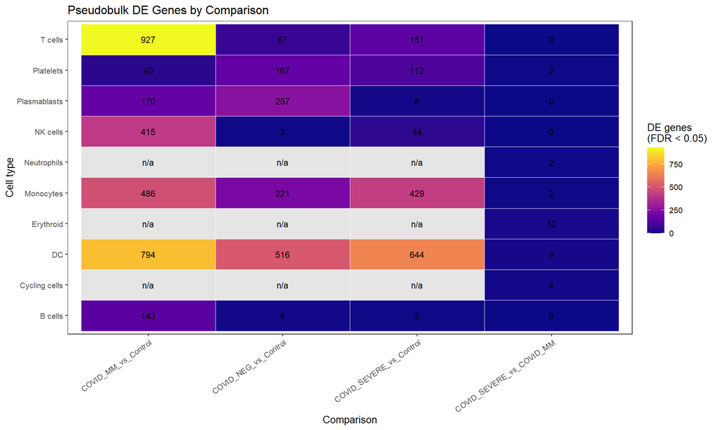

```r
p_de_counts <- ggplot(
  de_summary,
  aes(x = comparison, y = cell_type, fill = sig_genes)
) +
  geom_tile(color = "white") +
  geom_text(aes(label = ifelse(is.na(sig_genes), "n/a", sig_genes)), size = 3) +
  scale_fill_viridis_c(option = "C", name = "DE genes\n(FDR < 0.05)", na.value = "grey90") +
  labs(
    title = "Pseudobulk DE Genes by Comparison",
    x = "Comparison",
    y = "Cell type"
  ) +
  theme_bw(base_size = 10) +
  theme(
    axis.text.x = element_text(angle = 35, hjust = 1),
    panel.grid = element_blank()
  )

p_de_counts
```

# 22. GSEA (GO Biological Process)

Genes are ranked by the signed significance `sign(logFC) * -log10(PValue)` from the edgeR results, and `gseGO` is run with `eps = 0`. All pathways are kept in the table (`pvalueCutoff = 1`); significance is applied afterwards using `p.adjust < 0.05`.

```r
run_gsea_one <- function(tt) {

  p <- pmax(tt$PValue, 1e-300)
  ranks <- sign(tt$logFC) * -log10(p)
  names(ranks) <- tt$gene

  ranks <- ranks[is.finite(ranks)]
  ranks <- sort(ranks, decreasing = TRUE)

  if (length(ranks) < 200) return(NULL)

  res <- gseGO(
    geneList = ranks,
    OrgDb = org.Hs.eg.db,
    keyType = "SYMBOL",
    ont = "BP",
    minGSSize = 10,
    maxGSSize = 500,
    eps = 0,
    pvalueCutoff = 1,
    pAdjustMethod = "BH",
    verbose = FALSE,
    seed = TRUE
  )

  out <- as.data.frame(res)
  if (nrow(out) == 0) return(NULL)
  rownames(out) <- NULL
  out
}

if (!force_rerun && file.exists(gsea_file)) {

  gsea <- read.csv(gsea_file, check.names = FALSE)

} else {

  gsea_list <- list()

  for (ct in names(all_DE_results)) {
    for (cmp in names(all_DE_results[[ct]])) {

      tt <- all_DE_results[[ct]][[cmp]]$table
      if (is.null(tt)) next

      message("GSEA: ", ct, " | ", cmp)

      set.seed(42)
      res <- tryCatch(
        run_gsea_one(tt),
        error = function(e) {
          warning("GSEA failed for ", ct, " | ", cmp, ": ", conditionMessage(e))
          NULL
        }
      )

      if (!is.null(res)) {
        res$cell_type <- ct
        res$comparison <- cmp
        gsea_list[[paste(ct, cmp, sep = "|")]] <- res
      }
    }
  }

  gsea <- dplyr::bind_rows(gsea_list)

  if (nrow(gsea) == 0) {
    stop("GSEA produced no results. Check the DE summary above (too few samples per group?).")
  }

  write.csv(gsea, gsea_file, row.names = FALSE)
}

dim(gsea)
```

```
[1] 85854    14
```

```r
colnames(gsea)
```

```
 [1] "ID"              "Description"     "setSize"         "enrichmentScore"
 [5] "NES"             "pvalue"          "p.adjust"        "qvalue"
 [9] "rank"            "leading_edge"    "core_enrichment" "log2err"
[13] "cell_type"       "comparison"
```

```r
head(gsea[, c("cell_type", "comparison", "Description", "NES", "p.adjust")])
```

```
  cell_type          comparison
1   B cells COVID_MM_vs_Control
2   B cells COVID_MM_vs_Control
3   B cells COVID_MM_vs_Control
4   B cells COVID_MM_vs_Control
5   B cells COVID_MM_vs_Control
6   B cells COVID_MM_vs_Control
                                                           Description
1                                              cytoplasmic translation
2                                          striated muscle contraction
3 negative regulation of syncytium formation by plasma membrane fusion
4                               negative regulation of myoblast fusion
5                        syncytium formation by plasma membrane fusion
6                                                  syncytium formation
        NES     p.adjust
1 -3.011450 5.520454e-33
2 -2.787241 1.241313e-18
3 -2.781312 6.643280e-17
4 -2.781312 6.643280e-17
5 -2.695134 1.626292e-15
6 -2.695134 1.626292e-15
```

# 23. Significant GSEA pathways

```r
gsea_sig <- gsea %>%
  dplyr::filter(!is.na(p.adjust), p.adjust < 0.05)

nrow(gsea_sig)
```

```
[1] 5572
```

```r
pathway_counts <- gsea_sig %>%
  dplyr::count(comparison, cell_type, name = "significant_pathways")

all_grid <- expand.grid(
  comparison = names(comparisons),
  cell_type = sort(unique(gsea$cell_type)),
  stringsAsFactors = FALSE
)

pathway_counts <- all_grid %>%
  dplyr::left_join(pathway_counts, by = c("comparison", "cell_type")) %>%
  dplyr::mutate(significant_pathways = tidyr::replace_na(significant_pathways, 0L))

write.csv(
  pathway_counts,
  file.path(fig_dir, "GSEA_Significant_Pathway_Counts.csv"),
  row.names = FALSE
)

aggregate(
  significant_pathways ~ comparison,
  data = pathway_counts,
  FUN = sum
)
```

```
                comparison significant_pathways
1      COVID_MM_vs_Control                 2102
2     COVID_NEG_vs_Control                  799
3  COVID_SEVERE_vs_Control                 1466
4 COVID_SEVERE_vs_COVID_MM                 1205
```

# 24. Final GSEA figure

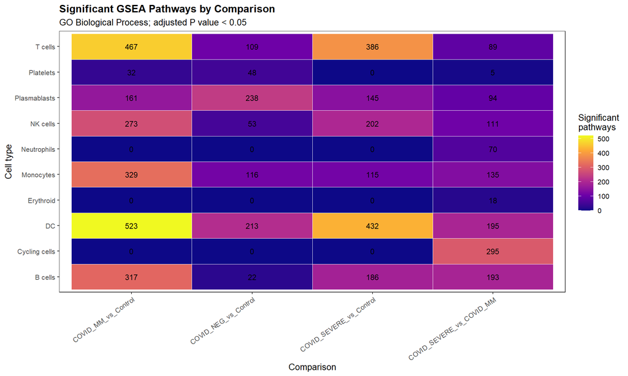

```r
p_gsea_counts <- ggplot(
  pathway_counts,
  aes(x = comparison, y = cell_type, fill = significant_pathways)
) +
  geom_tile(color = "white") +
  geom_text(aes(label = significant_pathways), size = 3) +
  scale_fill_viridis_c(option = "C", name = "Significant\npathways") +
  labs(
    title = "Significant GSEA Pathways by Comparison",
    subtitle = "GO Biological Process; adjusted P value < 0.05",
    x = "Comparison",
    y = "Cell type"
  ) +
  theme_bw(base_size = 10) +
  theme(
    plot.title = element_text(face = "bold"),
    axis.text.x = element_text(angle = 35, hjust = 1),
    panel.grid = element_blank()
  )

p_gsea_counts
```

# 25. Final object summary

```r
cat("Final dimensions:\n")
```

```
Final dimensions:
```

```r
print(dim(sepsis_full))
```

```
[1] 24850 84947
```

```r
cat("\nTotal cells:\n")
```

```
Total cells:
```

```r
print(ncol(sepsis_full))
```

```
[1] 84947
```

```r
cat("\nTotal features:\n")
```

```
Total features:
```

```r
print(nrow(sepsis_full))
```

```
[1] 24850
```

```r
cat("\nCell types:\n")
```

```
Cell types:
```

```r
print(sort(table(sepsis_full$cell_type), decreasing = TRUE))
```

```
  Neutrophils       T cells            DC      NK cells     Platelets
        24269         20318         10697         10583          7582
    Monocytes       B cells     Erythroid  Plasmablasts Cycling cells
         5749          2705          1822           878           344
```

```r
cat("\nClinical groups:\n")
```

```
Clinical groups:
```

```r
print(table(sepsis_full$group))
```

```
          Control          COVID_MM COVID_NEG_patient      COVID_SEVERE
            19003             19674              6419              8489
           Pooled
            31362
```

# 26. Save final Seurat object

```r
final_rds <- file.path(final_project_dir, "GSE163668_FINAL_seurat.rds")

saveRDS(sepsis_full, final_rds)

file.exists(final_rds)
```

```
[1] TRUE
```

# 27. Save final figures

```r
ggsave(
  file.path(fig_dir, "Figure1_UMAP_CellType.png"),
  p_umap_celltype, width = 13, height = 9, dpi = 300
)

ggsave(
  file.path(fig_dir, "Figure2_UMAP_Group.png"),
  p_umap_group, width = 11, height = 8, dpi = 300
)

ggsave(
  file.path(fig_dir, "Figure3_CellCounts_ByGroup.png"),
  p_group_counts, width = 9, height = 6, dpi = 300
)

ggsave(
  file.path(fig_dir, "Figure4_Composition_ByGroup.png"),
  p_composition, width = 14, height = 9, dpi = 300
)

ggsave(
  file.path(fig_dir, "Figure5_DE_Genes_ByComparison.png"),
  p_de_counts, width = 10, height = 6, dpi = 300
)

ggsave(
  file.path(fig_dir, "Figure6_GSEA_Significant_Pathways.png"),
  p_gsea_counts, width = 12, height = 8, dpi = 300
)
```

# 28. Final verification

```r
list.files(fig_dir, full.names = TRUE)
```

```
[1] "D:/SUBSPACE_data/GSE163668/FINAL_PROJECT/Final_Figures/Cell_type_proportions_per_sample.csv"
[2] "D:/SUBSPACE_data/GSE163668/FINAL_PROJECT/Final_Figures/Figure1_UMAP_CellType.png"
[3] "D:/SUBSPACE_data/GSE163668/FINAL_PROJECT/Final_Figures/Figure2_UMAP_Group.png"
[4] "D:/SUBSPACE_data/GSE163668/FINAL_PROJECT/Final_Figures/Figure3_CellCounts_ByGroup.png"
[5] "D:/SUBSPACE_data/GSE163668/FINAL_PROJECT/Final_Figures/Figure4_Composition_ByGroup.png"
[6] "D:/SUBSPACE_data/GSE163668/FINAL_PROJECT/Final_Figures/Figure5_DE_Genes_ByComparison.png"
[7] "D:/SUBSPACE_data/GSE163668/FINAL_PROJECT/Final_Figures/Figure6_GSEA_Significant_Pathways.png"
[8] "D:/SUBSPACE_data/GSE163668/FINAL_PROJECT/Final_Figures/GSEA_Significant_Pathway_Counts.csv"
```